# Tugas Pertemuan 4

Muhammad Fauzan Nur Rasendriya (G1401231108)

25 September 2025

```r
install_load <- function (package1, ...){
   packages <- c(package1, ...)
   for(package in packages){
       if(package %in% rownames(installed.packages())){
         do.call('library', list(package))
       }
       else{
          install.packages(package)
          do.call("library", list(package))
       }
   }
}

install_load("knitr","showtext","TSA")

opts_knit$set(root.dir = normalizePath("./"))

font_add_google("Lato", "lato")
showtext_auto()
```

```r
set.seed(1234)
n <- 300
wn <- rnorm(n)
```

# Proses MA(2)

## Bangkitkan model MA(2) dengan parameter θ₁ = 0.4 dan θ₂ = 0.6 sebanyak 300 data (manual dan menggunakan arima.sim()).

```r
# Manual
ma2 <- wn[1:2]
for(i in 3:n){
   ma2[i] <- wn[i] + 0.4*wn[i-1] + 0.6*wn[i-2]
}
ma2
```

```
##   [1] -1.207065749  0.277429242  0.471173424 -1.745463687  0.141510314
##   [6] -0.729712854 -0.114842790 -0.472894305 -1.127948717 -1.443797742
##  [11] -1.171879031 -1.723286222 -1.461924092 -0.845074607  0.519525249
##  [16]  0.312187420  0.020572732 -1.181770516 -1.508255550  1.534249256
##  [21]  0.598119283  1.012450498 -0.556369299 -0.011041246 -0.774213194
##  [26] -1.449939345 -0.420758391 -1.662676381 -0.079747157 -1.556197355
##  [31]  0.718835126 -0.596243221 -0.238298741 -1.070389923 -2.255260716
##  [36] -2.120011486 -3.624543435 -2.913580609 -2.138714925 -1.388210999
##  [41]  1.086560934 -0.768382742 -0.413123964 -1.263954490 -1.619808057
##  [46] -1.534624150 -2.091327966 -2.276021753 -1.689013389 -1.457572736
##  [51] -2.319068111 -1.602598402 -2.425338748 -1.807763414 -1.233628102
##  [56] -0.110845196  1.775654086  0.223607057  2.285258743 -0.979456751
##  [61]  1.157010823  2.116941328  1.378789117  0.845856907 -0.296314421
##  [66]  1.372262398 -0.432336811  1.978634754  1.193531021  1.688995021
##  [71]  0.939220832 -0.250827924 -0.544575725  0.228395751  2.109671129
```

[output cut: 45 more lines]

```r
# Dengan arima.sim
ma2_sim <- arima.sim(list(order=c(0,0,2), ma=c(0.4,0.6)), n=n)
ma2_sim
```

```
## Time Series:
## Start = 1
## End = 300
## Frequency = 1
##   [1] -0.908714261  0.366069559  0.319892749 -0.033692645 -0.749809541
##   [6]  1.023224875 -0.103827746  1.553027734  1.508813504  1.490258435
##  [11]  0.638775303  0.057508568 -0.761313741  1.006804154  0.046165301
##  [16]  2.226792228 -0.031351321  0.058227766 -0.452682262 -0.306828839
##  [21] -0.408896770 -1.768664231 -0.905163217 -1.653388217  0.814020129
##  [26] -0.949587092  1.394975120 -0.770061199  0.708742509  0.626264945
##  [31]  0.016220780  0.886163244 -0.177443664 -0.837739266 -0.776948985
##  [36]  0.830630275  0.271737011  0.068438994 -0.509614613 -0.182137038
##  [41]  1.054967504  1.724174690  1.131301118  1.891160132 -0.238116411
##  [46] -1.951472236 -1.868044756 -2.111236903 -2.805388403 -0.673455997
##  [51] -1.948408128 -0.202080988 -2.147789666 -0.222949385  1.157974906
```

[output cut: 49 more lines]

## Buat plot time series, plot ACF, plot PACF, dan plot EACF. Identifikasi apakah data tersebut stasioner.

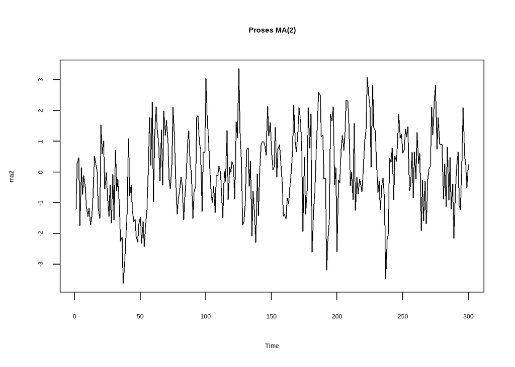

```r
ts.plot(ma2, main="Proses MA(2)")
```

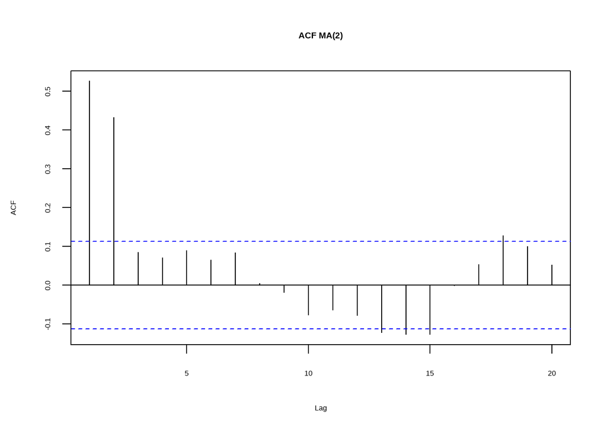

```r
acf(ma2, lag.max=20, main="ACF MA(2)")
```

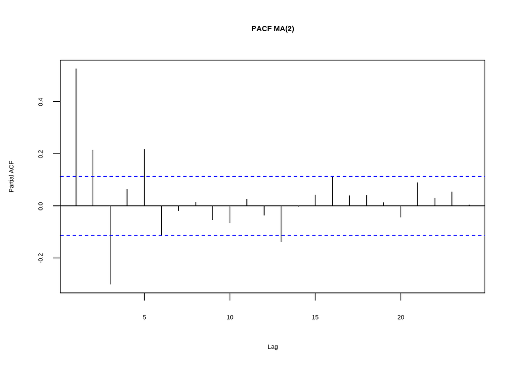

```r
pacf(ma2, main="PACF MA(2)")
```

```r
eacf(ma2)
```

```
## AR/MA
##   0 1 2 3 4 5 6 7 8 9 10 11 12 13
## 0 x x o o o o o o o o o  o  x  x
## 1 x x x o o o o o o o o  o  o  o
## 2 x x x x o o o o o o o  o  o  o
## 3 x x x x x o o o o o o  o  o  o
## 4 x x x x x o o o o o o  o  o  o
## 5 x x x x x o x o o o o  o  o  o
## 6 x x x o x o o x o o o  o  o  o
## 7 x o x o x o o x o o o  o  o  o
```

- Berdasarkan plot time series, terlihat bahwa model MA(2) yang dibangkitkan stasioner dalam rataan
- Berdasarkan plot ACF, terlihat bahwa plot ACF *cuts off* di lag kedua
- Berdasarkan plot PACF, terlihat bahwa plot PACF cenderung *tails off* dan membentuk gelombang sinus
- Berdasarkan pola segitiga nol pada plot EACF, terlihat bahwa segitiga nol berada pada ordo AR(0) dan ordo MA(2)

## Buat scatterplot antara Yₜ dengan Yₜ₋₁, Yₜ dengan Yₜ₋₂, serta Yₜ dengan Yₜ₋₃.

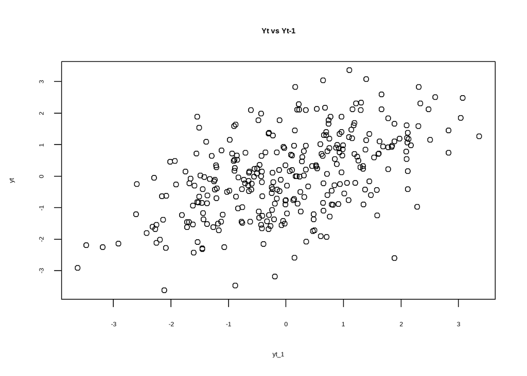

```r
# Scatterplot Yt vs lag
yt <- ma2[-1]
yt_1 <- ma2[-n]
plot(y=yt, x=yt_1, main="Yt vs Yt-1")
```

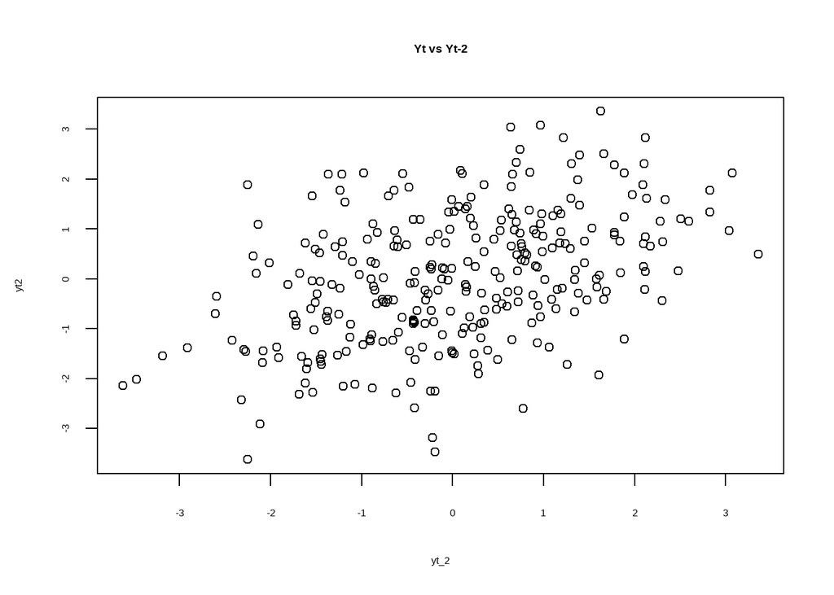

```r
yt2 <- ma2[-c(1,2)]
yt_2 <- ma2[-c((n-1),n)]
plot(y=yt2, x=yt_2, main="Yt vs Yt-2")
```

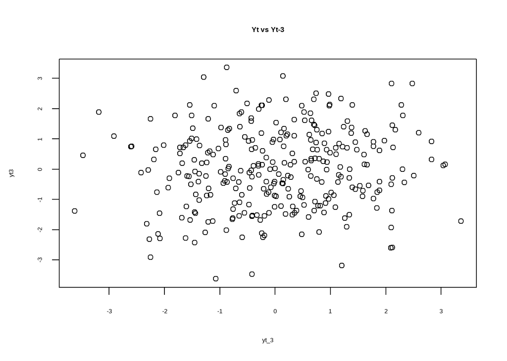

```r
yt3 <- ma2[-c(1,2,3)]
yt_3 <- ma2[-c((n-2),(n-1),n)]
plot(y=yt3, x=yt_3, main="Yt vs Yt-3")
```

Berdasarkan scatterplot tersebut, terlihat bahwa terdapat hubungan positif antara $Y_t$ dengan $Y_{t-1}$ dan $Y_t$ dengan $Y_{t-2}$.

```r
cor(yt, yt_1)
```

```
## [1] 0.5274606
```

```r
cor(yt2, yt_2)
```

```
## [1] 0.4339293
```

```r
cor(yt3, yt_3)
```

```
## [1] 0.08555282
```